[figure not shown]

# FUNDAMENTOS DE DATA SCIENCE, DATA MINING E ANÁLISE PREDITIVA

### Alunos: Ramsés Felipe de Oliveira e Dieison Rabêlo

## Um pouco sobre o Dataset

Estávamos analisando qual o dataset iriamos utilizar para realizar os procedimentos solicitados pelo professor Nauber, então ao verificarmos alguns dos que estavam disponíveis na internet, a maioria já possuiam algum tipo de analise e aplicações de modelos de machine learning. Então, uma aluna de fisioterapia que tinha realizado um trabalho de análise descritiva dos dados de pediatria de um hospital público do Estado do Ceará, pediu ajuda para analise desses dados. Dessa forma, considerando que após conversar com a estudante ela permitiu que eu pudessemos utilizar esses dados para eu aplicar alguns modelos. Ressaltamos que as informações foram retiradas dos prontuários dos pacientes e que para fins de publicações, deveremos submeter para análise do centro de estudos do orgão.

Este conjunto de dados nos mostra os registros médicos dos pacientes de um hospital da rede pública que foram acompanhados pelo setor de pediatria durante o período de 2016 e 2017. Vale ressaltar que trata-se de um hospital especializado procedimentos cardíacos e pulmonares.

### Informações sobre os atributos:

1. Idade(dias)
2. Qtd diagnosticos
3. Qtd cirurgias
4. RACHS
5. REOP
6. SEXO
7. PESO
8. DESFECHO

#### Carregando alguns dos pacotes que serão utilizados

```python
import pandas as pd
import numpy as np
import matplotlib.pyplot as plt
%matplotlib inline
import seaborn as sea
```

#### Carregando os dados

```python
dataset = pd.read_csv('dataset.csv')
dataset.shape
```

```
(469, 9)
```

```python
dataset.head()
```

|  | Id | Idade(dias) | Qtd diagnosticos | Qtd cirurgias | RACHS | REOP | SEXO | PESO | DESFECHO |
| --- | --- | --- | --- | --- | --- | --- | --- | --- | --- |
| 0 | 326 | 240 | 2 | NaN | 1 | 2 | 1 | 6.2 | 1 |
| 1 | 2 | 36 | 1 | 1.0 | 1 | 2 | 2 | 3.4 | 1 |
| 2 | 3 | 30 | 1 | 1.0 | 3 | 2 | 1 | 3.5 | 1 |
| 3 | 5 | 1460 | 1 | 1.0 | 1 | 2 | 2 | 16.0 | 1 |
| 4 | 6 | 2190 | 1 | 1.0 | 1 | 2 | 1 | 21.2 | 1 |

#### Transformando o 'Id' em indice

```python
dataset.index = dataset.Id
dataset = dataset.drop('Id', axis=1)
dataset.head()
```

| Id | Idade(dias) | Qtd diagnosticos | Qtd cirurgias | RACHS | REOP | SEXO | PESO | DESFECHO |
| --- | --- | --- | --- | --- | --- | --- | --- | --- |
| 326 | 240 | 2 | NaN | 1 | 2 | 1 | 6.2 | 1 |
| 2 | 36 | 1 | 1.0 | 1 | 2 | 2 | 3.4 | 1 |
| 3 | 30 | 1 | 1.0 | 3 | 2 | 1 | 3.5 | 1 |
| 5 | 1460 | 1 | 1.0 | 1 | 2 | 2 | 16.0 | 1 |
| 6 | 2190 | 1 | 1.0 | 1 | 2 | 1 | 21.2 | 1 |

# Analise Exploratória

#### Verificando valores missing

```python
dataset.isnull().any()
```

```
Idade(dias)         False
Qtd diagnosticos    False
Qtd cirurgias        True
RACHS               False
REOP                False
SEXO                False
PESO                False
DESFECHO            False
dtype: bool
```

#### Atribuindo valor (0) as missings

```python
dataset = dataset.fillna(0)
dataset.isnull().any()
```

```
Idade(dias)         False
Qtd diagnosticos    False
Qtd cirurgias       False
RACHS               False
REOP                False
SEXO                False
PESO                False
DESFECHO            False
dtype: bool
```

#### Verificando tipos dos dados

```python
dataset.dtypes
```

```
Idade(dias)           int64
Qtd diagnosticos      int64
Qtd cirurgias       float64
RACHS                 int64
REOP                  int64
SEXO                  int64
PESO                float64
DESFECHO              int64
dtype: object
```

#### Algumas estatísticas

```python
dataset.describe()
```

|  | Idade(dias) | Qtd diagnosticos | Qtd cirurgias | RACHS | REOP | SEXO | PESO | DESFECHO |
| --- | --- | --- | --- | --- | --- | --- | --- | --- |
| count | 469.000000 | 469.000000 | 469.000000 | 469.000000 | 469.000000 | 469.000000 | 469.000000 | 469.000000 |
| mean | 1074.773987 | 1.720682 | 1.541578 | 2.454158 | 1.880597 | 1.469083 | 12.408529 | 1.121535 |
| std | 1602.762108 | 0.903944 | 0.793186 | 1.076422 | 0.324608 | 0.499576 | 13.062771 | 0.327097 |
| min | 1.000000 | 1.000000 | 0.000000 | 1.000000 | 1.000000 | 1.000000 | 1.800000 | 1.000000 |
| 25% | 73.000000 | 1.000000 | 1.000000 | 2.000000 | 2.000000 | 1.000000 | 3.800000 | 1.000000 |
| 50% | 270.000000 | 1.000000 | 1.000000 | 3.000000 | 2.000000 | 1.000000 | 7.000000 | 1.000000 |
| 75% | 1460.000000 | 2.000000 | 2.000000 | 3.000000 | 2.000000 | 2.000000 | 16.300000 | 1.000000 |
| max | 6571.000000 | 6.000000 | 4.000000 | 6.000000 | 2.000000 | 2.000000 | 69.000000 | 2.000000 |

#### Agrupando os resultados por desfecho (y)

```python
dataset.groupby('DESFECHO').size()
```

```
DESFECHO
1    412
2     57
dtype: int64
```

#### Apresentando a correlação entre as features

```python
dataset.corr(method = 'pearson')
```

|  | Idade(dias) | Qtd diagnosticos | Qtd cirurgias | RACHS | REOP | SEXO | PESO | DESFECHO |
| --- | --- | --- | --- | --- | --- | --- | --- | --- |
| Idade(dias) | 1.000000 | -0.120386 | 0.027989 | -0.198975 | 0.063196 | -0.000465 | 0.934789 | -0.190098 |
| Qtd diagnosticos | -0.120386 | 1.000000 | 0.363419 | 0.225077 | 0.031737 | -0.035724 | -0.138719 | 0.086150 |
| Qtd cirurgias | 0.027989 | 0.363419 | 1.000000 | 0.261885 | -0.063666 | -0.016970 | -0.003499 | 0.042250 |
| RACHS | -0.198975 | 0.225077 | 0.261885 | 1.000000 | -0.156349 | -0.083104 | -0.240848 | 0.395151 |
| REOP | 0.063196 | 0.031737 | -0.063666 | -0.156349 | 1.000000 | -0.009636 | 0.073611 | -0.185022 |
| SEXO | -0.000465 | -0.035724 | -0.016970 | -0.083104 | -0.009636 | 1.000000 | -0.030148 | -0.101179 |
| PESO | 0.934789 | -0.138719 | -0.003499 | -0.240848 | 0.073611 | -0.030148 | 1.000000 | -0.201026 |
| DESFECHO | -0.190098 | 0.086150 | 0.042250 | 0.395151 | -0.185022 | -0.101179 | -0.201026 | 1.000000 |

#### Plotando alguns gráficos para análise visual

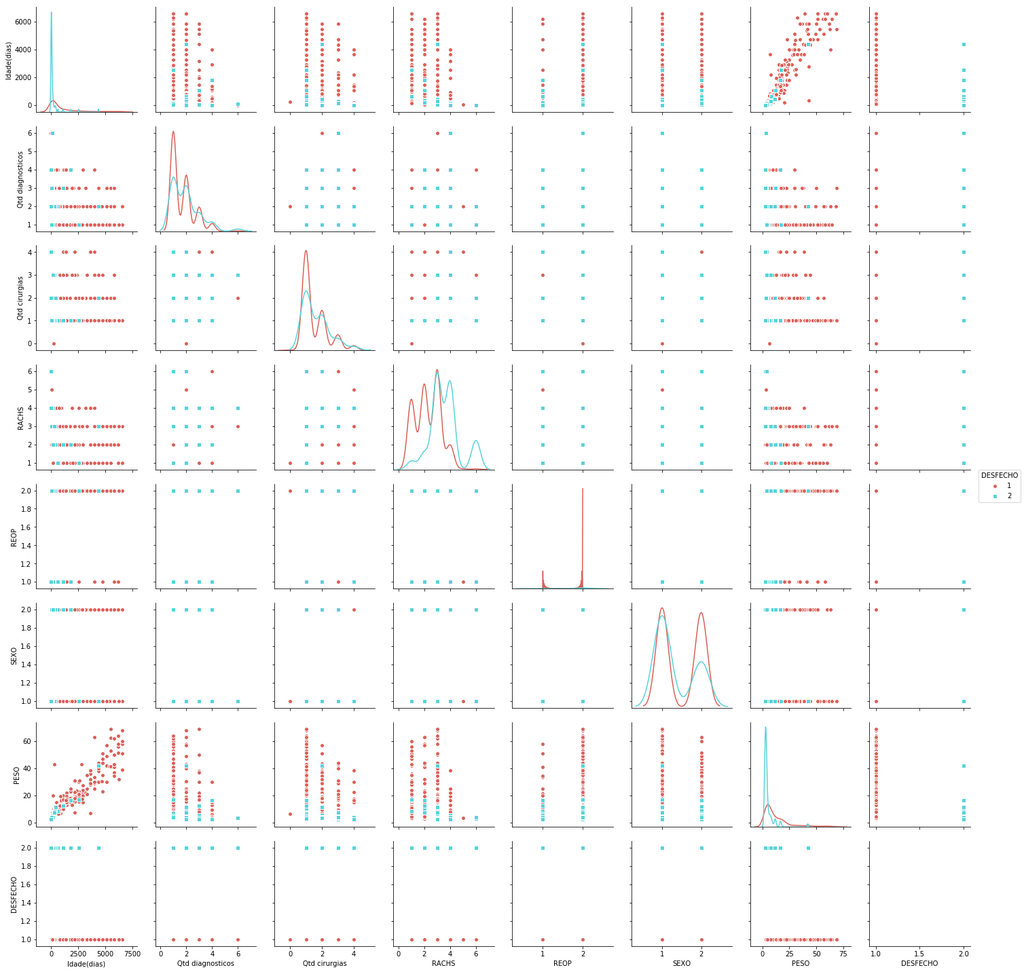

```python
sea.pairplot(dataset, hue="DESFECHO",markers=["o","s"],diag_kind="kde",palette="hls")
```

#### Considerando que trata-se de um dataset de pediatria, selecionamos menores de 18 anos

```python
planilhaMenoresDe18 = dataset[dataset['Idade(dias)'] < 6571]
dataset.shape
```

```
(469, 8)
```

#### Verificando os nomes da colunas

```python
dataset.columns
```

```
Index(['Idade(dias)', 'Qtd diagnosticos', 'Qtd cirurgias', 'RACHS', 'REOP',
       'SEXO', 'PESO', 'DESFECHO'],
      dtype='object')
```

#### Aplicando alguns modelos

```
LR: 0.884089 (0.042729)
LDA: 0.884089 (0.042729)
NB: 0.791628 (0.095435)
KNN: 0.867021 (0.046588)
CART: 0.824098 (0.044010)
SVM: 0.879972 (0.032443)
```

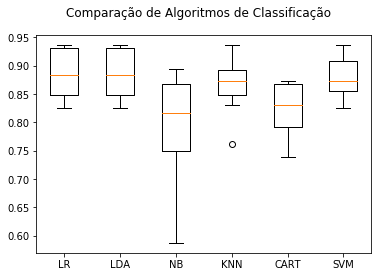

```python
# Import dos módulos
import matplotlib.pyplot as plt
from sklearn import cross_validation
from sklearn.linear_model import LogisticRegression
from sklearn.tree import DecisionTreeClassifier
from sklearn.neighbors import KNeighborsClassifier
from sklearn.discriminant_analysis import LinearDiscriminantAnalysis
from sklearn.naive_bayes import GaussianNB
from sklearn.svm import SVC

array = planilhaMenoresDe18.values

# Separando o array em componentes de input e output
X = array[:,0:7]
Y = array[:,7]

# Definindo os valores para o número de folds
num_folds = 10
num_instances = len(X)
seed = 7

# Preparando os modelos ( (esta criando uma lista de modelos))
modelos = []
modelos.append(('LR', LogisticRegression()))
modelos.append(('LDA', LinearDiscriminantAnalysis()))
modelos.append(('NB', GaussianNB()))
modelos.append(('KNN', KNeighborsClassifier()))
modelos.append(('CART', DecisionTreeClassifier()))
modelos.append(('SVM', SVC()))

# Avaliando cada modelo
resultados = []
nomes = []

for nome, modelo in modelos:
    kfold = cross_validation.KFold(n = num_instances, n_folds = num_folds, random_state = seed)
    cv_results = cross_validation.cross_val_score(modelo, X, Y, cv = kfold, scoring = 'accuracy')
    resultados.append(cv_results)
    nomes.append(nome)
    msg = "%s: %f (%f)" % (nome, cv_results.mean(), cv_results.std())
    print(msg)

# Boxplot para comparar os algoritmos
fig = plt.figure()
fig.suptitle('Comparação de Algoritmos de Classificação')
ax = fig.add_subplot(111)
plt.boxplot(resultados)
ax.set_xticklabels(nomes)
plt.show()
```

#### Confusion Matrix sobre o modelo escolhido (Logistic Regression)

```python
# Import dos módulos
from sklearn import model_selection
from sklearn.linear_model import LogisticRegression
from sklearn.model_selection import cross_val_predict
from sklearn.metrics import confusion_matrix

array = planilhaMenoresDe18.values

# Separando o array em componentes de input e output
X = array[:,0:7]
Y = array[:,7]

# Definindo os valores para o número de folds
num_folds = 10
num_instances = len(X)
random_state = 7

# Separando os dados em folds
kfold = model_selection.KFold(num_folds, True, random_state = random_state)

# Criando o modelo
modelo = LogisticRegression()
results = model_selection.cross_val_score(modelo, X, Y, cv = kfold)
modelo.fit(X,Y)

# Print do resultado
print(results.mean())


# Fazendo as previsões e construindo a Confusion Matrix
y_pred = cross_val_predict(modelo, X, Y, cv = kfold)
matrix = confusion_matrix(Y, y_pred)


# Imprimindo a Confusion Matrix
print(matrix)
```

```
0.8842275670675301
[[403   7]
 [ 47  10]]
```

#### Alterando Escala

Utilizaremos - Escala

Esta etapa também é chamada de normalização e significa colocar os dados em uma escala com range entre 0 e 1. Isso é útil para a otimização. Isso também é útil para algoritmos como regressão e redes neurais e algoritmos que usam medidas de distância, como KNN. O scikit-learn possui uma função para esta etapa, chamada MinMaxScaler().

```python
from sklearn import preprocessing
```

```python
minmax_scale = preprocessing.MinMaxScaler(feature_range=(0, 1))
x_scale = minmax_scale.fit_transform(planilhaMenoresDe18)
planilhaComEscalaAlterada= pd.DataFrame(x_scale)
planilhaComEscalaAlterada.head()
```

|  | 0 | 1 | 2 | 3 | 4 | 5 | 6 | 7 |
| --- | --- | --- | --- | --- | --- | --- | --- | --- |
| 0 | 0.036383 | 0.2 | 0.00 | 0.0 | 1.0 | 0.0 | 0.065476 | 0.0 |
| 1 | 0.005328 | 0.0 | 0.25 | 0.0 | 1.0 | 1.0 | 0.023810 | 0.0 |
| 2 | 0.004415 | 0.0 | 0.25 | 0.4 | 1.0 | 0.0 | 0.025298 | 0.0 |
| 3 | 0.222104 | 0.0 | 0.25 | 0.0 | 1.0 | 1.0 | 0.211310 | 0.0 |
| 4 | 0.333232 | 0.0 | 0.25 | 0.0 | 1.0 | 0.0 | 0.288690 | 0.0 |

#### Aplicando alguns modelos com a escala alterada

```
LR: 0.886216 (0.044695)
LDA: 0.884089 (0.042729)
NB: 0.791628 (0.095435)
KNN: 0.871415 (0.049187)
CART: 0.809112 (0.048656)
SVM: 0.877798 (0.035084)
```

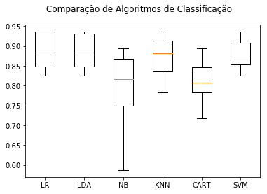

```python
array = planilhaComEscalaAlterada.values

# Separando o array em componentes de input e output
X = array[:,0:7]
Y = array[:,7]

# Definindo os valores para o número de folds
num_folds = 10
num_instances = len(X)
seed = 7

# Preparando os modelos (por ramses (esta criando uma lista de modelos))
modelos = []
modelos.append(('LR', LogisticRegression()))
modelos.append(('LDA', LinearDiscriminantAnalysis()))
modelos.append(('NB', GaussianNB()))
modelos.append(('KNN', KNeighborsClassifier()))
modelos.append(('CART', DecisionTreeClassifier()))
modelos.append(('SVM', SVC()))

# Avaliando cada modelo
resultados = []
nomes = []

for nome, modelo in modelos:
    kfold = cross_validation.KFold(n = num_instances, n_folds = num_folds, random_state = seed)
    cv_results = cross_validation.cross_val_score(modelo, X, Y, cv = kfold, scoring = 'accuracy')
    resultados.append(cv_results)
    nomes.append(nome)
    msg = "%s: %f (%f)" % (nome, cv_results.mean(), cv_results.std())
    print(msg)

# Boxplot para comparar os algoritmos
fig = plt.figure()
fig.suptitle('Comparação de Algoritmos de Classificação')
ax = fig.add_subplot(111)
plt.boxplot(resultados)
ax.set_xticklabels(nomes)
plt.show()
```

#### Confusion Matrix com a escala alterada e modelo Logistic Regression

```python
array = planilhaComEscalaAlterada.values

# Separando o array em componentes de input e output
X = array[:,0:7]
Y = array[:,7]

# Definindo os valores para o número de folds
num_folds = 10
num_instances = len(X)
random_state = 7

# Separando os dados em folds
kfold = model_selection.KFold(num_folds, True, random_state = random_state)

# Criando o modelo
modelo = LogisticRegression()
results = model_selection.cross_val_score(modelo, X, Y, cv = kfold)
modelo.fit(X,Y)

# Print do resultado
print(results.mean())


# Fazendo as previsões e construindo a Confusion Matrix
y_pred = cross_val_predict(modelo, X, Y, cv = kfold)
matrix = confusion_matrix(Y, y_pred)


# Imprimindo a Confusion Matrix
print(matrix)
```

```
0.8863552266419982
[[405   5]
 [ 48   9]]
```

Feature Selection

Feature Selection é onde selecionamos os atributos (variáveis) que serão melhores candidatas a variáveis preditoras. O Feature Selection nos ajuda a reduzir o overfitting (quando o algoritmo aprende demais), aumenta a acurácia do modelo e reduz o tempo de treinamento.

### Seleção Univariada

Testes estatísticos podem ser usados para selecionar os atributos que possuem forte relacionamento com a variável que estamos tentando prever. O Scikit-learn fornece a função SelectKBest() que pode ser usada com diversos testes estatísticos, para selecionar os atributos. Vamos usar o teste qui-quadrado. Vamos selecionar os 4 melhores atributos que podem ser usados como variáveis preditoras.

```python
# Extração de Variáveis com Testes Estatísticos Univariados (Teste qui-quadrado)

# Import dos módulos

from sklearn.feature_selection import SelectKBest
from sklearn.feature_selection import chi2

array = dataset.values

# Separando o array em componentes de input e output
X = array[:,0:7]
Y = array[:,7]

# Extração de Variáveis
test = SelectKBest(score_func = chi2, k = 4)
fit = test.fit(X, Y)

# Sumarizando o score

print(fit.scores_)
features = fit.transform(X)

# Sumarizando atributos selecionados
print(features[0:5,:])

dataset.head()
```

```
[4.04223460e+04 1.64942806e+00 3.40942292e-01 3.45011671e+01
 8.97670281e-01 8.13921729e-01 2.60077414e+02]
[[2.40e+02 2.00e+00 1.00e+00 6.20e+00]
 [3.60e+01 1.00e+00 1.00e+00 3.40e+00]
 [3.00e+01 1.00e+00 3.00e+00 3.50e+00]
 [1.46e+03 1.00e+00 1.00e+00 1.60e+01]
 [2.19e+03 1.00e+00 1.00e+00 2.12e+01]]
```

| Id | Idade(dias) | Qtd diagnosticos | Qtd cirurgias | RACHS | REOP | SEXO | PESO | DESFECHO |
| --- | --- | --- | --- | --- | --- | --- | --- | --- |
| 326 | 240 | 2 | 0.0 | 1 | 2 | 1 | 6.2 | 1 |
| 2 | 36 | 1 | 1.0 | 1 | 2 | 2 | 3.4 | 1 |
| 3 | 30 | 1 | 1.0 | 3 | 2 | 1 | 3.5 | 1 |
| 5 | 1460 | 1 | 1.0 | 1 | 2 | 2 | 16.0 | 1 |
| 6 | 2190 | 1 | 1.0 | 1 | 2 | 1 | 21.2 | 1 |

### Eliminação Recursiva de Atributos

Esta é outra técnica para seleção de atributos, que recursivamente remove os atributos e constrói o modelo com os atributos remanescentes. Esta técnica utiliza a acurácia do modelo para identificar os atributos que mais contribuem para prever a variável alvo.

```python
# Eliminação Recursiva de Variáveis

# Import dos módulos

from sklearn.feature_selection import RFE
from sklearn.linear_model import LogisticRegression

array = dataset.values

# Separando o array em componentes de input e output
X = array[:,0:7]
Y = array[:,7]

# Criação do modelo
modelo = LogisticRegression()

# RFE
rfe = RFE(modelo, 3)
fit = rfe.fit(X, Y)

# Print dos resultados
print("Número de Atributos: %d" % fit.n_features_)
print(dataset.columns[0:7])
print("Atributos Selecionados: %s" % fit.support_)
print("Ranking dos Atributos: %s" % fit.ranking_)
```

```
Número de Atributos: 3
Index(['Idade(dias)', 'Qtd diagnosticos', 'Qtd cirurgias', 'RACHS', 'REOP',
       'SEXO', 'PESO'],
      dtype='object')
Atributos Selecionados: [False False False  True  True  True False]
Ranking dos Atributos: [5 4 2 1 1 1 3]
```

### Método Ensemble para Seleção de Variáveis

Bagged Decision Trees, como o algoritmo RandomForest, podem ser usados para estimar a importância de cada atributo. Esse método retorna um score para cada atributo.

Quanto maior o score, maior a importância do atributo.

```python
# Importância do Atributo com o Extra Trees Classifier

# Import dos Módulos

from sklearn.ensemble import ExtraTreesClassifier

array = dataset.values

# Separando o array em componentes de input e output
X = array[:,0:7]
Y = array[:,7]

# Criação do Modelo - Feature Selection
modelo = ExtraTreesClassifier()
modelo.fit(X, Y)

# Print dos Resultados
print(dataset.columns[0:7])
print(modelo.feature_importances_)
```

```
Index(['Idade(dias)', 'Qtd diagnosticos', 'Qtd cirurgias', 'RACHS', 'REOP',
       'SEXO', 'PESO'],
      dtype='object')
[0.2482004  0.11818684 0.07492856 0.19934432 0.04094532 0.04510993
 0.27328463]
```

Na primeira parte deste Notebook, passamos por varios procedimentos para tentarmos da melhor forma conseguirmos bons resultados, mas notamos que mesmo com uma boa acuracia, o modelo continua a errar bastante o percentual de obitos. Desta forma, procuramos melhorar o modelo adicionando mais dados, que são os procedimentos realizados e os diagnosticos dados a cada paciente, assim abaixo retornamos a fase exploratoria e adicionamos mais etapas afim de encontrar um melhor resultado.

### Adicionamos um dataset das cirurgias realizadas e outro de diagnosticos dos pacientes

Novos datasets

Cirurgias => Atributos (id, Nome_Cirurgia)

Diagnostico => Atributos (id, Nome_Diagnostico)

```python
cirurgias = pd.read_csv('cirurgias.csv')
cirurgias = cirurgias[["Índice","CIRURGIAS"]]
cirurgias.index = cirurgias['Índice']
cirurgias = cirurgias['CIRURGIAS']
cirurgias = pd.DataFrame(cirurgias)
print("Quantidade de informações: " , cirurgias.shape)
cirurgias.head(2)
```

```
Quantidade de informações:  (718, 1)
```

| Índice | CIRURGIAS |
| --- | --- |
| 99 | ASP OU ASR |
| 98 | ASP OU ASR |

### Convertendo categorias nominais colunas

```python
CirurgiasModificada = pd.get_dummies(cirurgias["CIRURGIAS"])
print("Quantidade de informações: " , CirurgiasModificada.shape)
CirurgiasModificada.head(2)
```

```
Quantidade de informações:  (718, 45)
```

| Índice | ALARGAMENTO | AMPLIAÇÃO | ANASTOMOSE | AORTOPLASTIA | ARTRIOSSEPTECTOMIA | ASO | ASP OU ASR | BAP | BH | BI-GLENN | ... | RASTELLI | RE-IMPLANTE | REDIRECIONAMENTO | RESSECÇÃO | SANO | SENNING | SHUNT | TUNELIZAÇÃO | UNIFOCALIZAÇÃO | VSP OU VSR |
| --- | --- | --- | --- | --- | --- | --- | --- | --- | --- | --- | --- | --- | --- | --- | --- | --- | --- | --- | --- | --- | --- |
| 99 | 0 | 0 | 0 | 0 | 0 | 0 | 1 | 0 | 0 | 0 | ... | 0 | 0 | 0 | 0 | 0 | 0 | 0 | 0 | 0 | 0 |
| 98 | 0 | 0 | 0 | 0 | 0 | 0 | 1 | 0 | 0 | 0 | ... | 0 | 0 | 0 | 0 | 0 | 0 | 0 | 0 | 0 | 0 |

2 rows × 45 columns

```python
cirurgiasRealizadas = CirurgiasModificada.groupby(CirurgiasModificada.index).sum()
print("Quantidade de cirurgias realizadas: " , cirurgiasRealizadas.shape)
cirurgiasRealizadas.head(2)
```

```
Quantidade de cirurgias realizadas:  (468, 45)
```

| Índice | ALARGAMENTO | AMPLIAÇÃO | ANASTOMOSE | AORTOPLASTIA | ARTRIOSSEPTECTOMIA | ASO | ASP OU ASR | BAP | BH | BI-GLENN | ... | RASTELLI | RE-IMPLANTE | REDIRECIONAMENTO | RESSECÇÃO | SANO | SENNING | SHUNT | TUNELIZAÇÃO | UNIFOCALIZAÇÃO | VSP OU VSR |
| --- | --- | --- | --- | --- | --- | --- | --- | --- | --- | --- | --- | --- | --- | --- | --- | --- | --- | --- | --- | --- | --- |
| 1 | 0 | 0 | 0 | 0 | 0 | 0 | 0 | 0 | 0 | 0 | ... | 0 | 0 | 0 | 0 | 0 | 0 | 0 | 0 | 1 | 0 |
| 2 | 0 | 0 | 0 | 0 | 0 | 0 | 0 | 0 | 0 | 0 | ... | 0 | 0 | 0 | 0 | 0 | 0 | 0 | 0 | 0 | 0 |

2 rows × 45 columns

```python
diagnosticos = pd.read_csv('diagnosticos.csv')
diagnosticos = diagnosticos[["Índice","CARDIOPATIAS"]]
diagnosticos.index = diagnosticos['Índice']
diagnosticos = diagnosticos['CARDIOPATIAS']
diagnosticos = pd.DataFrame(diagnosticos)
print("Quantidade de informações: " , diagnosticos.shape)
diagnosticos.head(2)
```

```
Quantidade de informações:  (807, 1)
```

| Índice | CARDIOPATIAS |
| --- | --- |
| 99 | COMUNICAÇÃO INTERATRIAL |
| 98 | COMUNICAÇÃO INTERATRIAL |

```python
diagnosticosModificada = pd.get_dummies(diagnosticos["CARDIOPATIAS"])
print("Quantidade de informações: " , diagnosticosModificada.shape)
diagnosticosModificada.head(2)
```

```
Quantidade de informações:  (807, 45)
```

| Índice | ATRESIA MITRAL | ATRESIA PULMONAR | ATRESIA TRICUSPIDE( IA, IIA, IB, IIB, IC, IIC) | BLOQUEIO ATRIO VENTRICULAR | COARCTAÇÃO DA AORTA | COLATERAIS | COMUNICAÇÃO INTERATRIAL | COMUNICAÇÃO INTERVENTRICULAR | DEFEITO DE SEPTO ATRIO-VENTRICULAR | DISFUNÇÃO VENTRICULAR | ... | PERSISTÊNCIA DO CANAL ARTERIAL | REGURGITAÇÃO VALVULA | RRPP HIPOPLASICOS | SINDROME DA HIPOPLASIA DO VENTRÍCULO ESQUERDO | TRANSPOSIÇÃO DE GRANDES ARTÉRIAS | TRETALOGIA DE FALLOT | TRUNCUS (TODOS OS TIPOS) | VALVULA UNICA | VE HIPOPLASICO | VENTRICULO ÚNICO |
| --- | --- | --- | --- | --- | --- | --- | --- | --- | --- | --- | --- | --- | --- | --- | --- | --- | --- | --- | --- | --- | --- |
| 99 | 0 | 0 | 0 | 0 | 0 | 0 | 1 | 0 | 0 | 0 | ... | 0 | 0 | 0 | 0 | 0 | 0 | 0 | 0 | 0 | 0 |
| 98 | 0 | 0 | 0 | 0 | 0 | 0 | 1 | 0 | 0 | 0 | ... | 0 | 0 | 0 | 0 | 0 | 0 | 0 | 0 | 0 | 0 |

2 rows × 45 columns

```python
diagnosticosRealizadas = diagnosticosModificada.groupby(diagnosticosModificada.index).sum()
print("Quantidade de cirurgias realizadas: " , diagnosticosRealizadas.shape)
diagnosticosRealizadas.head(2)
```

```
Quantidade de cirurgias realizadas:  (469, 45)
```

| Índice | ATRESIA MITRAL | ATRESIA PULMONAR | ATRESIA TRICUSPIDE( IA, IIA, IB, IIB, IC, IIC) | BLOQUEIO ATRIO VENTRICULAR | COARCTAÇÃO DA AORTA | COLATERAIS | COMUNICAÇÃO INTERATRIAL | COMUNICAÇÃO INTERVENTRICULAR | DEFEITO DE SEPTO ATRIO-VENTRICULAR | DISFUNÇÃO VENTRICULAR | ... | PERSISTÊNCIA DO CANAL ARTERIAL | REGURGITAÇÃO VALVULA | RRPP HIPOPLASICOS | SINDROME DA HIPOPLASIA DO VENTRÍCULO ESQUERDO | TRANSPOSIÇÃO DE GRANDES ARTÉRIAS | TRETALOGIA DE FALLOT | TRUNCUS (TODOS OS TIPOS) | VALVULA UNICA | VE HIPOPLASICO | VENTRICULO ÚNICO |
| --- | --- | --- | --- | --- | --- | --- | --- | --- | --- | --- | --- | --- | --- | --- | --- | --- | --- | --- | --- | --- | --- |
| 1 | 0 | 1 | 0 | 0 | 0 | 1 | 0 | 1 | 0 | 0 | ... | 0 | 0 | 0 | 0 | 0 | 0 | 0 | 0 | 0 | 0 |
| 2 | 0 | 0 | 0 | 0 | 1 | 0 | 0 | 0 | 0 | 0 | ... | 0 | 0 | 0 | 0 | 0 | 0 | 0 | 0 | 0 | 0 |

2 rows × 45 columns

### Realizando um merge dos dois datasets

```python
datasetUnificado = diagnosticosRealizadas.join(cirurgiasRealizadas)
print(datasetUnificado.shape)
datasetUnificado.head(2)
```

```
(469, 90)
```

| Índice | ATRESIA MITRAL | ATRESIA PULMONAR | ATRESIA TRICUSPIDE( IA, IIA, IB, IIB, IC, IIC) | BLOQUEIO ATRIO VENTRICULAR | COARCTAÇÃO DA AORTA | COLATERAIS | COMUNICAÇÃO INTERATRIAL | COMUNICAÇÃO INTERVENTRICULAR | DEFEITO DE SEPTO ATRIO-VENTRICULAR | DISFUNÇÃO VENTRICULAR | ... | RASTELLI | RE-IMPLANTE | REDIRECIONAMENTO | RESSECÇÃO | SANO | SENNING | SHUNT | TUNELIZAÇÃO | UNIFOCALIZAÇÃO | VSP OU VSR |
| --- | --- | --- | --- | --- | --- | --- | --- | --- | --- | --- | --- | --- | --- | --- | --- | --- | --- | --- | --- | --- | --- |
| 1 | 0 | 1 | 0 | 0 | 0 | 1 | 0 | 1 | 0 | 0 | ... | 0.0 | 0.0 | 0.0 | 0.0 | 0.0 | 0.0 | 0.0 | 0.0 | 1.0 | 0.0 |
| 2 | 0 | 0 | 0 | 0 | 1 | 0 | 0 | 0 | 0 | 0 | ... | 0.0 | 0.0 | 0.0 | 0.0 | 0.0 | 0.0 | 0.0 | 0.0 | 0.0 | 0.0 |

2 rows × 90 columns

### Unificando os 03 datasets

```python
datasetCompleto = planilhaMenoresDe18.join(datasetUnificado)
print(datasetCompleto.shape)
datasetCompleto.head(2)
```

```
(467, 98)
```

| Id | Idade(dias) | Qtd diagnosticos | Qtd cirurgias | RACHS | REOP | SEXO | PESO | DESFECHO | ATRESIA MITRAL | ATRESIA PULMONAR | ... | RASTELLI | RE-IMPLANTE | REDIRECIONAMENTO | RESSECÇÃO | SANO | SENNING | SHUNT | TUNELIZAÇÃO | UNIFOCALIZAÇÃO | VSP OU VSR |
| --- | --- | --- | --- | --- | --- | --- | --- | --- | --- | --- | --- | --- | --- | --- | --- | --- | --- | --- | --- | --- | --- |
| 326 | 240 | 2 | 0.0 | 1 | 2 | 1 | 6.2 | 1 | 0 | 0 | ... | NaN | NaN | NaN | NaN | NaN | NaN | NaN | NaN | NaN | NaN |
| 2 | 36 | 1 | 1.0 | 1 | 2 | 2 | 3.4 | 1 | 0 | 0 | ... | 0.0 | 0.0 | 0.0 | 0.0 | 0.0 | 0.0 | 0.0 | 0.0 | 0.0 | 0.0 |

2 rows × 98 columns

#### Tratando dados faltantes

```python
print(datasetCompleto.isnull().any().tail())
```

```
SENNING           True
SHUNT             True
TUNELIZAÇÃO       True
UNIFOCALIZAÇÃO    True
VSP OU VSR        True
dtype: bool
```

```python
datasetCompleto = datasetCompleto.fillna(0)
print(datasetCompleto.isnull().any().tail())
```

```
SENNING           False
SHUNT             False
TUNELIZAÇÃO       False
UNIFOCALIZAÇÃO    False
VSP OU VSR        False
dtype: bool
```

```python
datasetCompleto['DESFECHO02'] = datasetCompleto['DESFECHO']
print(datasetCompleto.shape)
datasetCompleto.head(2)
```

```
(467, 99)
```

| Id | Idade(dias) | Qtd diagnosticos | Qtd cirurgias | RACHS | REOP | SEXO | PESO | DESFECHO | ATRESIA MITRAL | ATRESIA PULMONAR | ... | RE-IMPLANTE | REDIRECIONAMENTO | RESSECÇÃO | SANO | SENNING | SHUNT | TUNELIZAÇÃO | UNIFOCALIZAÇÃO | VSP OU VSR | DESFECHO02 |
| --- | --- | --- | --- | --- | --- | --- | --- | --- | --- | --- | --- | --- | --- | --- | --- | --- | --- | --- | --- | --- | --- |
| 326 | 240 | 2 | 0.0 | 1 | 2 | 1 | 6.2 | 1 | 0 | 0 | ... | 0.0 | 0.0 | 0.0 | 0.0 | 0.0 | 0.0 | 0.0 | 0.0 | 0.0 | 1 |
| 2 | 36 | 1 | 1.0 | 1 | 2 | 2 | 3.4 | 1 | 0 | 0 | ... | 0.0 | 0.0 | 0.0 | 0.0 | 0.0 | 0.0 | 0.0 | 0.0 | 0.0 | 1 |

2 rows × 99 columns

#### Exibindo todas as colunas do novo dataset resultante

```python
datasetCompleto.columns
```

```
Index(['Idade(dias)', 'Qtd diagnosticos', 'Qtd cirurgias', 'RACHS', 'REOP',
       'SEXO', 'PESO', 'DESFECHO', 'ATRESIA MITRAL', 'ATRESIA PULMONAR',
       'ATRESIA TRICUSPIDE( IA, IIA, IB, IIB, IC, IIC)',
       'BLOQUEIO ATRIO VENTRICULAR', 'COARCTAÇÃO DA AORTA', 'COLATERAIS',
       'COMUNICAÇÃO INTERATRIAL', 'COMUNICAÇÃO INTERVENTRICULAR',
       'DEFEITO DE SEPTO ATRIO-VENTRICULAR', 'DISFUNÇÃO VENTRICULAR',
       'DRENAGEM ANOMALA DE VEIAS PULMONARES',
       'DUPLA LESÃO DE VALVULA (mitral/Ao)',
       'DUPLA VIA DE SAIDA DO VENTRICULO DIREITO',
       'DUPLA VIA DE SAÍDA DO VENTRICULO UNICO', 'DVE', 'EBSTEIN',
       'ESTENOSE AO', 'ESTENOSE MITRAL', 'ESTENOSE MITRAL EMI',
       'ESTENOSE PULMONAR', 'ESTENOSE RRPP', 'ESTENOSE SUBAORTICA',
       'ESTENOSE TUBO VD-TP', 'HIPERTENSÃO PULMONAR',
       'HIPOPLASIA ARCO AORTICO', 'HIPOPLASIA MITRAL', 'INSUF. AO',
       'INSUF. TRICUSPIDE', 'INSUF. VALVULA', 'INSUFICIÊNCIA MITRAL',
       'INTERRUPÇAO ARCO AO', 'ISOMERISMO ATRIAL',
       'MIOCARDIOPATIA HIPERTROFICA', 'ORIGEM ANOMALA DA CORONARIA', 'Outros',
       'PERSISTÊNCIA DO CANAL ARTERIAL', 'REGURGITAÇÃO VALVULA',
       'RRPP HIPOPLASICOS', 'SINDROME DA HIPOPLASIA DO VENTRÍCULO ESQUERDO',
       'TRANSPOSIÇÃO DE GRANDES ARTÉRIAS', 'TRETALOGIA DE FALLOT',
       'TRUNCUS (TODOS OS TIPOS)', 'VALVULA UNICA', 'VE HIPOPLASICO',
       'VENTRICULO ÚNICO', 'ALARGAMENTO', 'AMPLIAÇÃO', 'ANASTOMOSE',
       'AORTOPLASTIA', 'ARTRIOSSEPTECTOMIA', 'ASO', 'ASP OU ASR', 'BAP', 'BH',
       'BI-GLENN', 'BROCK', 'BT OU BTM', 'CERCLAGEM DE AP',
       'CERCLAGEM DE RRPP', 'COARTECTOMIA', 'COMISSUTOROMIA',
       'CORREÇÃO DATVVPP', 'CORREÇÃO DSAV-T', 'CORREÇÃO T4F', 'FBV',
       'FECHAMENTO JANELA AO-PULM.', 'FECHAMENTO PARCIAL DA', 'FONTAN',
       'GLENN', 'IMPLANTE DE MCP', 'INFUNDIBULECTOMIA', 'INSTALAÇÃO ECMO',
       'INTERPOSIÇÃO DE TUBO', 'JATENE', 'LIGADURA', 'NORWOOD',
       'OUTRAS CORREÇÕES', 'PLASTIA', 'PONTE', 'PRÓTESE', 'RASTELLI',
       'RE-IMPLANTE', 'REDIRECIONAMENTO', 'RESSECÇÃO', 'SANO', 'SENNING',
       'SHUNT', 'TUNELIZAÇÃO', 'UNIFOCALIZAÇÃO', 'VSP OU VSR', 'DESFECHO02'],
      dtype='object')
```

```python
datasetCompleto = datasetCompleto.drop('DESFECHO', axis=1)
datasetCompleto.shape
```

```
(467, 98)
```

### Considerando que agora temos um grande conjunto de dados, vamos realizar uma análise estatística de correlação e p_valor para explorarmos os novos dados

```python
from scipy import stats
```

```python
correlacao = []
p_valor = []
col01 = []
col02 = []
teste = []
tabela = [col01,col02,correlacao,p_valor,teste]
for i in datasetCompleto.columns:
    a = datasetCompleto[i]
    for j in datasetCompleto.columns:
        b = datasetCompleto[j]
        correlacao.append(stats.pearsonr(a,b)[0])
        p_valor.append(stats.pearsonr(a,b)[1])
        col01.append(i)
        col02.append(j)
        if i == j:
            teste.append('Excluir')
        else:
            teste.append('ok')
```

```python
Dados = pd.DataFrame(tabela)
Relatorio = np.transpose(Dados)
Relatorio.columns = ['col01','col02','correlacao','p_valor','teste']
RelatorioTratado = Relatorio.loc[(Relatorio["teste"] == 'ok')]
RelatorioTratado.sort_values('correlacao',ascending=False).head(10)
```

|  | col01 | col02 | correlacao | p_valor | teste |
| --- | --- | --- | --- | --- | --- |
| 1056 | BLOQUEIO ATRIO VENTRICULAR | IMPLANTE DE MCP | 1 | 0 | ok |
| 7458 | IMPLANTE DE MCP | BLOQUEIO ATRIO VENTRICULAR | 1 | 0 | ok |
| 6 | Idade(dias) | PESO | 0.931574 | 1.82483e-206 | ok |
| 588 | PESO | Idade(dias) | 0.931574 | 1.82483e-206 | ok |
| 1144 | COARCTAÇÃO DA AORTA | COARTECTOMIA | 0.896912 | 6.7889e-167 | ok |
| 6479 | COARTECTOMIA | COARCTAÇÃO DA AORTA | 0.896912 | 6.7889e-167 | ok |
| 1539 | DEFEITO DE SEPTO ATRIO-VENTRICULAR | CORREÇÃO DSAV-T | 0.833154 | 1.06929e-121 | ok |
| 6777 | CORREÇÃO DSAV-T | DEFEITO DE SEPTO ATRIO-VENTRICULAR | 0.833154 | 1.06929e-121 | ok |
| 4676 | TRETALOGIA DE FALLOT | CORREÇÃO T4F | 0.739705 | 5.06479e-82 | ok |
| 6907 | CORREÇÃO T4F | TRETALOGIA DE FALLOT | 0.739705 | 5.06479e-82 | ok |

```python
novoDatasetTeste = datasetCompleto[['Idade(dias)', 'Qtd diagnosticos', 'Qtd cirurgias', 'RACHS', 'REOP',
       'SEXO', 'PESO','BLOQUEIO ATRIO VENTRICULAR','IMPLANTE DE MCP','COARCTAÇÃO DA AORTA',
                                    'COARTECTOMIA', 'DESFECHO02']]
novoDatasetTeste.head()
```

| Id | Idade(dias) | Qtd diagnosticos | Qtd cirurgias | RACHS | REOP | SEXO | PESO | BLOQUEIO ATRIO VENTRICULAR | IMPLANTE DE MCP | COARCTAÇÃO DA AORTA | COARTECTOMIA | DESFECHO02 |
| --- | --- | --- | --- | --- | --- | --- | --- | --- | --- | --- | --- | --- |
| 326 | 240 | 2 | 0.0 | 1 | 2 | 1 | 6.2 | 0 | 0.0 | 0 | 0.0 | 1 |
| 2 | 36 | 1 | 1.0 | 1 | 2 | 2 | 3.4 | 0 | 0.0 | 1 | 1.0 | 1 |
| 3 | 30 | 1 | 1.0 | 3 | 2 | 1 | 3.5 | 0 | 0.0 | 0 | 0.0 | 1 |
| 5 | 1460 | 1 | 1.0 | 1 | 2 | 2 | 16.0 | 0 | 0.0 | 0 | 0.0 | 1 |
| 6 | 2190 | 1 | 1.0 | 1 | 2 | 1 | 21.2 | 0 | 0.0 | 1 | 1.0 | 1 |

```python
verificando = novoDatasetTeste[novoDatasetTeste['BLOQUEIO ATRIO VENTRICULAR'] == 1]
print(verificando.shape)
print(verificando.groupby('IMPLANTE DE MCP').size())
verificando.head()
```

```
(4, 12)
IMPLANTE DE MCP
1.0    4
dtype: int64
```

| Id | Idade(dias) | Qtd diagnosticos | Qtd cirurgias | RACHS | REOP | SEXO | PESO | BLOQUEIO ATRIO VENTRICULAR | IMPLANTE DE MCP | COARCTAÇÃO DA AORTA | COARTECTOMIA | DESFECHO02 |
| --- | --- | --- | --- | --- | --- | --- | --- | --- | --- | --- | --- | --- |
| 399 | 2190 | 2 | 2.0 | 3 | 2 | 2 | 15.6 | 1 | 1.0 | 0 | 0.0 | 1 |
| 413 | 20 | 6 | 2.0 | 3 | 2 | 1 | 3.8 | 1 | 1.0 | 0 | 0.0 | 1 |
| 455 | 270 | 2 | 2.0 | 1 | 2 | 1 | 10.0 | 1 | 1.0 | 0 | 0.0 | 1 |
| 346 | 330 | 3 | 3.0 | 3 | 2 | 2 | 7.0 | 1 | 1.0 | 0 | 0.0 | 1 |

```python
verificando02 = novoDatasetTeste[novoDatasetTeste['COARCTAÇÃO DA AORTA'] == 1]
print(verificando02.shape)
print(verificando02.groupby('COARTECTOMIA').size())
verificando02.head()
```

```
(57, 12)
COARTECTOMIA
0.0     9
1.0    48
dtype: int64
```

| Id | Idade(dias) | Qtd diagnosticos | Qtd cirurgias | RACHS | REOP | SEXO | PESO | BLOQUEIO ATRIO VENTRICULAR | IMPLANTE DE MCP | COARCTAÇÃO DA AORTA | COARTECTOMIA | DESFECHO02 |
| --- | --- | --- | --- | --- | --- | --- | --- | --- | --- | --- | --- | --- |
| 2 | 36 | 1 | 1.0 | 1 | 2 | 2 | 3.4 | 0 | 0.0 | 1 | 1.0 | 1 |
| 6 | 2190 | 1 | 1.0 | 1 | 2 | 1 | 21.2 | 0 | 0.0 | 1 | 1.0 | 1 |
| 27 | 6205 | 1 | 1.0 | 1 | 2 | 1 | 56.0 | 0 | 0.0 | 1 | 0.0 | 1 |
| 29 | 26 | 1 | 1.0 | 1 | 2 | 1 | 3.4 | 0 | 0.0 | 1 | 1.0 | 1 |
| 63 | 150 | 1 | 1.0 | 1 | 2 | 2 | 3.9 | 0 | 0.0 | 1 | 1.0 | 1 |

### Da mesma forma que realizamos com o primeiro dataset, o proximo passo aplicaremos novamente os mesmos modelos.

#### OBS.: O novo dataset possui 98 colunas

```
LR: 0.881961 (0.047777)
LDA: 0.849815 (0.046949)
```

```
NB: 0.704810 (0.052203)
KNN: 0.867068 (0.042129)
CART: 0.817761 (0.053365)
SVM: 0.877798 (0.035084)
```

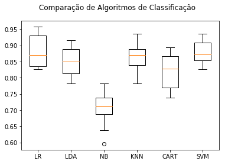

```python
array = datasetCompleto.values

# Separando o array em componentes de input e output
X = array[:,0:97]
Y = array[:,97]

# Definindo os valores para o número de folds
num_folds = 10
num_instances = len(X)
seed = 7

# Preparando os modelos (por ramses (esta criando uma lista de modelos))
modelos = []
modelos.append(('LR', LogisticRegression()))
modelos.append(('LDA', LinearDiscriminantAnalysis()))
modelos.append(('NB', GaussianNB()))
modelos.append(('KNN', KNeighborsClassifier()))
modelos.append(('CART', DecisionTreeClassifier()))
modelos.append(('SVM', SVC()))

# Avaliando cada modelo
resultados = []
nomes = []

for nome, modelo in modelos:
    kfold = cross_validation.KFold(n = num_instances, n_folds = num_folds, random_state = seed)
    cv_results = cross_validation.cross_val_score(modelo, X, Y, cv = kfold, scoring = 'accuracy')
    resultados.append(cv_results)
    nomes.append(nome)
    msg = "%s: %f (%f)" % (nome, cv_results.mean(), cv_results.std())
    print(msg)

# Boxplot para comparar os algoritmos
fig = plt.figure()
fig.suptitle('Comparação de Algoritmos de Classificação')
ax = fig.add_subplot(111)
plt.boxplot(resultados)
ax.set_xticklabels(nomes)
plt.show()
```

#### Confusion matrix do dataset completo

```python
array = datasetCompleto.values

# Separando o array em componentes de input e output
X = array[:,0:97]
Y = array[:,97]

# Definindo os valores para o número de folds
num_folds = 10
num_instances = len(X)
random_state = 7

# Separando os dados em folds
kfold = model_selection.KFold(num_folds, True, random_state = random_state)

# Criando o modelo
modelo = LogisticRegression()
results = model_selection.cross_val_score(modelo, X, Y, cv = kfold)
modelo.fit(X,Y)

# Print do resultado
print(results.mean())


# Fazendo as previsões e construindo a Confusion Matrix
y_pred = cross_val_predict(modelo, X, Y, cv = kfold)
matrix = confusion_matrix(Y, y_pred)


# Imprimindo a Confusion Matrix
print(matrix)
```

```
0.8865402405180388
[[398  12]
 [ 41  16]]
```

```python
minmax_scale = preprocessing.MinMaxScaler(feature_range=(0, 1))
x_scale2 = minmax_scale.fit_transform(datasetCompleto)
planilhaComEscalaAlteradaGeral= pd.DataFrame(x_scale2)
planilhaComEscalaAlteradaGeral.head(2)
```

|  | 0 | 1 | 2 | 3 | 4 | 5 | 6 | 7 | 8 | 9 | ... | 88 | 89 | 90 | 91 | 92 | 93 | 94 | 95 | 96 | 97 |
| --- | --- | --- | --- | --- | --- | --- | --- | --- | --- | --- | --- | --- | --- | --- | --- | --- | --- | --- | --- | --- | --- |
| 0 | 0.036383 | 0.2 | 0.00 | 0.0 | 1.0 | 0.0 | 0.065476 | 0.0 | 0.0 | 0.0 | ... | 0.0 | 0.0 | 0.0 | 0.0 | 0.0 | 0.0 | 0.0 | 0.0 | 0.0 | 0.0 |
| 1 | 0.005328 | 0.0 | 0.25 | 0.0 | 1.0 | 1.0 | 0.023810 | 0.0 | 0.0 | 0.0 | ... | 0.0 | 0.0 | 0.0 | 0.0 | 0.0 | 0.0 | 0.0 | 0.0 | 0.0 | 0.0 |

2 rows × 98 columns

#### Testando modelos com o dataset com escala alterada

```
LR: 0.892646 (0.041551)
LDA: 0.849815 (0.046949)
NB: 0.287558 (0.082897)
KNN: 0.886170 (0.052547)
CART: 0.834875 (0.043982)
```

```
SVM: 0.877798 (0.035084)
```

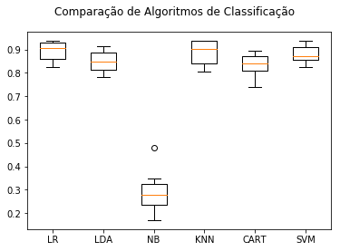

```python
array = planilhaComEscalaAlteradaGeral.values

# Separando o array em componentes de input e output
X = array[:,0:97]
Y = array[:,97]

# Definindo os valores para o número de folds
num_folds = 10
num_instances = len(X)
seed = 7

# Preparando os modelos (por ramses (esta criando uma lista de modelos))
modelos = []
modelos.append(('LR', LogisticRegression()))
modelos.append(('LDA', LinearDiscriminantAnalysis()))
modelos.append(('NB', GaussianNB()))
modelos.append(('KNN', KNeighborsClassifier()))
modelos.append(('CART', DecisionTreeClassifier()))
modelos.append(('SVM', SVC()))

# Avaliando cada modelo
resultados = []
nomes = []

for nome, modelo in modelos:
    kfold = cross_validation.KFold(n = num_instances, n_folds = num_folds, random_state = seed)
    cv_results = cross_validation.cross_val_score(modelo, X, Y, cv = kfold, scoring = 'accuracy')
    resultados.append(cv_results)
    nomes.append(nome)
    msg = "%s: %f (%f)" % (nome, cv_results.mean(), cv_results.std())
    print(msg)

# Boxplot para comparar os algoritmos
fig = plt.figure()
fig.suptitle('Comparação de Algoritmos de Classificação')
ax = fig.add_subplot(111)
plt.boxplot(resultados)
ax.set_xticklabels(nomes)
plt.show()
```

#### Confusion Matrix com escala alterada no modelo -> LogisticRegression

```python
array = planilhaComEscalaAlteradaGeral.values

# Separando o array em componentes de input e output
X = array[:,0:97]
Y = array[:,97]

# Definindo os valores para o número de folds
num_folds = 10
num_instances = len(X)
random_state = 7

# Separando os dados em folds
kfold = model_selection.KFold(num_folds, True, random_state = random_state)

# Criando o modelo
modelo = LogisticRegression()
results = model_selection.cross_val_score(modelo, X, Y, cv = kfold)
modelo.fit(X,Y)

# Print do resultado
print(results.mean())


# Fazendo as previsões e construindo a Confusion Matrix
y_pred = cross_val_predict(modelo, X, Y, cv = kfold)
matrix = confusion_matrix(Y, y_pred)


# Imprimindo a Confusion Matrix
print(matrix)
```

```
0.8907493061979649
[[401   9]
 [ 42  15]]
```

#### Confusion Matrix com escala alterada no modelo -> KNeighborsClassifier

```python
# Import dos módulos
from sklearn import model_selection
from sklearn.neighbors import KNeighborsClassifier
from sklearn.model_selection import cross_val_predict
from sklearn.metrics import confusion_matrix

array = planilhaComEscalaAlteradaGeral.values

# Separando o array em componentes de input e output
X = array[:,0:97]
Y = array[:,97]

# Definindo os valores para o número de folds
num_folds = 10
num_instances = len(X)
random_state = 7

# Separando os dados em folds
kfold = model_selection.KFold(num_folds, True, random_state = random_state)

# Criando o modelo
modelo = KNeighborsClassifier()
results = model_selection.cross_val_score(modelo, X, Y, cv = kfold)
modelo.fit(X,Y)

# Print do resultado
print(results.mean())


# Fazendo as previsões e construindo a Confusion Matrix
y_pred = cross_val_predict(modelo, X, Y, cv = kfold)
matrix = confusion_matrix(Y, y_pred)


# Imprimindo a Confusion Matrix
print(matrix)
```

```
0.8950508788159113
[[402   8]
 [ 41  16]]
```

## Upsampling a minoria para a maioria

```python
from sklearn.utils import resample
```

```python
# Separate majority and minority classes
df_maioria = datasetCompleto[datasetCompleto.DESFECHO02==1]
df_minoria = datasetCompleto[datasetCompleto.DESFECHO02==2]

qtd_maioria = len(df_maioria)
qtd_minoria = len(df_minoria)

# Upsample minority class
df_minoria_upsampled = resample(df_minoria,
                         replace=True,     # sample with replacement
                         n_samples=qtd_maioria,    # to match majority class
                         random_state=123) # reproducible results

# Combine majority class with upsampled minority class
df_upsampled = pd.concat([df_maioria, df_minoria_upsampled])

# Display new class counts
df_upsampled.DESFECHO02.value_counts()
```

```
2    410
1    410
Name: DESFECHO02, dtype: int64
```

```python
df_upsampled.shape
```

```
(820, 98)
```

### Testando vários modelos para UpSampled

```
LR: 0.817073 (0.079409)
LDA: 0.810976 (0.079829)
NB: 0.756098 (0.187186)
KNN: 0.859756 (0.131261)
```

```
CART: 0.882927 (0.184562)
SVM: 0.826829 (0.112539)
```

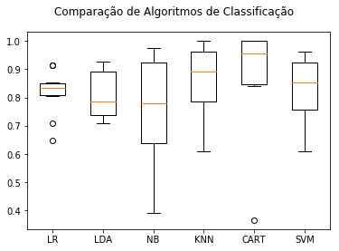

```python
array = df_upsampled.values

# Separando o array em componentes de input e output
X = array[:,0:97]
Y = array[:,97]

# Definindo os valores para o número de folds
num_folds = 10
num_instances = len(X)
seed = 7

# Preparando os modelos (esta criando uma lista de modelos)
modelos = []
modelos.append(('LR', LogisticRegression()))
modelos.append(('LDA', LinearDiscriminantAnalysis()))
modelos.append(('NB', GaussianNB()))
modelos.append(('KNN', KNeighborsClassifier()))
modelos.append(('CART', DecisionTreeClassifier()))
modelos.append(('SVM', SVC()))

# Avaliando cada modelo
resultados = []
nomes = []

for nome, modelo in modelos:
    kfold = cross_validation.KFold(n = num_instances, n_folds = num_folds, random_state = seed)
    cv_results = cross_validation.cross_val_score(modelo, X, Y, cv = kfold, scoring = 'accuracy')
    resultados.append(cv_results)
    nomes.append(nome)
    msg = "%s: %f (%f)" % (nome, cv_results.mean(), cv_results.std())
    print(msg)

# Boxplot para comparar os algoritmos
fig = plt.figure()
fig.suptitle('Comparação de Algoritmos de Classificação')
ax = fig.add_subplot(111)
plt.boxplot(resultados)
ax.set_xticklabels(nomes)
plt.show()
```

## Confusion Matrix (UpSampled)

```python
array = df_upsampled.values

# Separando o array em componentes de input e output
X = array[:,0:97]
Y = array[:,97]

# Definindo os valores para o número de folds
num_folds = 10
num_instances = len(X)
random_state = 7

# Separando os dados em folds
kfold = model_selection.KFold(num_folds, True, random_state = random_state)

# Criando o modelo
modelo = DecisionTreeClassifier()
results = model_selection.cross_val_score(modelo, X, Y, cv = kfold)
modelo.fit(X,Y)

# Print do resultado
print(results.mean())


# Fazendo as previsões e construindo a Confusion Matrix
y_pred = cross_val_predict(modelo, X, Y, cv = kfold)
matrix = confusion_matrix(Y, y_pred)


# Imprimindo a Confusion Matrix
print(matrix)
```

```
0.9560975609756099
[[372  38]
 [  0 410]]
```

## Downsampling da maioria pra minoria

```python
# Downsample majority class
df_maioria_downsampled = resample(df_maioria,
                                 replace=False,    # sample without replacement
                                 n_samples=qtd_minoria,     # to match minority class
                                 random_state=123) # reproducible results

# Combine minority class with downsampled majority class
df_downsampled = pd.concat([df_maioria_downsampled, df_minoria])

# Display new class counts
df_downsampled.DESFECHO02.value_counts()
```

```
2    57
1    57
Name: DESFECHO02, dtype: int64
```

### Testando vários modelos para Downsampling

```
LR: 0.726515 (0.103289)
LDA: 0.684091 (0.094745)
NB: 0.767424 (0.139157)
KNN: 0.675000 (0.117873)
CART: 0.719697 (0.073995)
SVM: 0.596212 (0.080606)
```

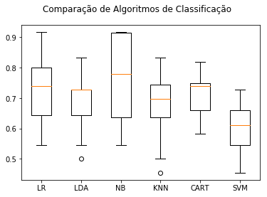

```python
array = df_downsampled.values

# Separando o array em componentes de input e output
X = array[:,0:97]
Y = array[:,97]

# Definindo os valores para o número de folds
num_folds = 10
num_instances = len(X)
seed = 7

# Preparando os modelos (esta criando uma lista de modelos)
modelos = []
modelos.append(('LR', LogisticRegression()))
modelos.append(('LDA', LinearDiscriminantAnalysis()))
modelos.append(('NB', GaussianNB()))
modelos.append(('KNN', KNeighborsClassifier()))
modelos.append(('CART', DecisionTreeClassifier()))
modelos.append(('SVM', SVC()))

# Avaliando cada modelo
resultados = []
nomes = []

for nome, modelo in modelos:
    kfold = cross_validation.KFold(n = num_instances, n_folds = num_folds, random_state = seed)
    cv_results = cross_validation.cross_val_score(modelo, X, Y, cv = kfold, scoring = 'accuracy')
    resultados.append(cv_results)
    nomes.append(nome)
    msg = "%s: %f (%f)" % (nome, cv_results.mean(), cv_results.std())
    print(msg)

# Boxplot para comparar os algoritmos
fig = plt.figure()
fig.suptitle('Comparação de Algoritmos de Classificação')
ax = fig.add_subplot(111)
plt.boxplot(resultados)
ax.set_xticklabels(nomes)
plt.show()
```

### Confusion Matrix para Downsampled

```python
array = df_downsampled.values

# Separando o array em componentes de input e output
X = array[:,0:97]
Y = array[:,97]

# Definindo os valores para o número de folds
num_folds = 10
num_instances = len(X)
random_state = 7

# Separando os dados em folds
kfold = model_selection.KFold(num_folds, True, random_state = random_state)

# Criando o modelo
modelo = GaussianNB()
results = model_selection.cross_val_score(modelo, X, Y, cv = kfold)
modelo.fit(X,Y)

# Print do resultado
print(results.mean())


# Fazendo as previsões e construindo a Confusion Matrix
y_pred = cross_val_predict(modelo, X, Y, cv = kfold)
matrix = confusion_matrix(Y, y_pred)


# Imprimindo a Confusion Matrix
print(matrix)
```

```
0.7924242424242425
[[51  6]
 [18 39]]
```

### Dividindo em dados de treino e teste

#### Sem escala alterada (dataset)

```python
array = datasetCompleto.values

# Separando o array em componentes de input e output
X = array[:,0:97]
Y = array[:,97]


teste_size = 0.3

seed = 7

# Preparando os modelos (por ramses (esta criando uma lista de modelos))
modelos = []
modelos.append(('LR', LogisticRegression()))
modelos.append(('LDA', LinearDiscriminantAnalysis()))
modelos.append(('NB', GaussianNB()))
modelos.append(('KNN', KNeighborsClassifier()))
modelos.append(('CART', DecisionTreeClassifier()))
modelos.append(('SVM', SVC()))

# Avaliando cada modelo
resultados = []
nomes = []

X_treino, X_teste, Y_treino, Y_teste = model_selection.train_test_split(X, Y,
                                                                         test_size = teste_size,
                                                                         random_state = seed)

for nome, modelo in modelos:

    modelo.fit(X_treino, Y_treino)
    result = modelo.score(X_teste, Y_teste)
    resultados.append(result)
    nomes.append(nome)
    print(nome, "Acurácia: %.3f%%" % (result * 100.0))
```

```
LR Acurácia: 88.652%
LDA Acurácia: 87.234%
NB Acurácia: 70.213%
KNN Acurácia: 86.525%
CART Acurácia: 85.106%
SVM Acurácia: 89.362%
```

```python
array = datasetCompleto.values
print("Quantidade de Registros: ",datasetCompleto.shape[0])
print()
print("---")

# Separando o array em componentes de input e output
X = array[:,0:97]
Y = array[:,97]

teste_size = 0.3

X_treino, X_teste, Y_treino, Y_teste = model_selection.train_test_split(X, Y,
                                                                         test_size = teste_size,
                                                                         random_state = seed)


print("Quantidade de Registros Treino: ", X_treino.shape[0])
print()
print("---")
print("Quantidade de Registros de Teste: ", X_teste.shape[0])
print()
print("---")

# Criando o modelo
modelos = []
modelos.append(('LR', LogisticRegression()))
modelos.append(('LDA', LinearDiscriminantAnalysis()))
modelos.append(('NB', GaussianNB()))
modelos.append(('KNN', KNeighborsClassifier()))
modelos.append(('CART', DecisionTreeClassifier()))
modelos.append(('SVM', SVC()))



resultados = []
nomes = []
for nome, modelo in modelos:
    print(nome)

    modelo.fit(X_treino, Y_treino)
    result = modelo.score(X_teste, Y_teste)
    print(result.mean())
    previsoes = modelo.predict(X_teste)
    matrix = confusion_matrix(Y_teste, previsoes)
    print(matrix)

    print("---")
```

```
Quantidade de Registros:  467

---
Quantidade de Registros Treino:  326

---
Quantidade de Registros de Teste:  141

---
LR
0.8865248226950354
[[122   4]
 [ 12   3]]
---
LDA
0.8723404255319149
[[120   6]
 [ 12   3]]
---
NB
0.7021276595744681
[[92 34]
 [ 8  7]]
---
KNN
0.8652482269503546
[[122   4]
 [ 15   0]]
---
CART
0.8439716312056738
[[115  11]
 [ 11   4]]
---
SVM
0.8936170212765957
[[126   0]
 [ 15   0]]
---
```

#### Dados normalizados

```python
array = planilhaComEscalaAlteradaGeral.values

# Separando o array em componentes de input e output
X = array[:,0:97]
Y = array[:,97]


teste_size = 0.3

seed = 7

# Preparando os modelos (por ramses (esta criando uma lista de modelos))
modelos = []
modelos.append(('LR', LogisticRegression()))
modelos.append(('LDA', LinearDiscriminantAnalysis()))
modelos.append(('NB', GaussianNB()))
modelos.append(('KNN', KNeighborsClassifier()))
modelos.append(('CART', DecisionTreeClassifier()))
modelos.append(('SVM', SVC()))

# Avaliando cada modelo
resultados = []
nomes = []

X_treino, X_teste, Y_treino, Y_teste = model_selection.train_test_split(X, Y,
                                                                         test_size = teste_size,
                                                                         random_state = seed)

for nome, modelo in modelos:

    modelo.fit(X_treino, Y_treino)
    result = modelo.score(X_teste, Y_teste)
    resultados.append(result)
    nomes.append(nome)
    print(nome, "Acurácia: %.3f%%" % (result * 100.0))
```

```
LR Acurácia: 89.362%
LDA Acurácia: 87.234%
NB Acurácia: 34.752%
KNN Acurácia: 90.071%
CART Acurácia: 87.234%
SVM Acurácia: 89.362%
```

```python
array = planilhaComEscalaAlteradaGeral.values
print("Quantidade de Registros: ",planilhaComEscalaAlteradaGeral.shape[0])
print()
print("---")

# Separando o array em componentes de input e output
X = array[:,0:97]
Y = array[:,97]

teste_size = 0.3

X_treino, X_teste, Y_treino, Y_teste = model_selection.train_test_split(X, Y,
                                                                         test_size = teste_size,
                                                                         random_state = seed)


print("Quantidade de Registros Treino: ", X_treino.shape[0])
print()
print("---")
print("Quantidade de Registros de Teste: ", X_teste.shape[0])
print()
print("---")

# Criando o modelo
modelos = []
modelos.append(('LR', LogisticRegression()))
modelos.append(('LDA', LinearDiscriminantAnalysis()))
modelos.append(('NB', GaussianNB()))
modelos.append(('KNN', KNeighborsClassifier()))
modelos.append(('CART', DecisionTreeClassifier()))
modelos.append(('SVM', SVC()))



resultados = []
nomes = []
for nome, modelo in modelos:
    print(nome)

    modelo.fit(X_treino, Y_treino)
    result = modelo.score(X_teste, Y_teste)
    print(result.mean())
    previsoes = modelo.predict(X_teste)
    matrix = confusion_matrix(Y_teste, previsoes)
    print(matrix)

    print("---")
```

```
Quantidade de Registros:  467

---
Quantidade de Registros Treino:  326

---
Quantidade de Registros de Teste:  141

---
LR
0.8936170212765957
[[124   2]
 [ 13   2]]
---
LDA
0.8723404255319149
[[120   6]
 [ 12   3]]
---
NB
0.3475177304964539
[[39 87]
 [ 5 10]]
---
KNN
0.900709219858156
[[124   2]
 [ 12   3]]
---
CART
0.8368794326241135
[[115  11]
 [ 12   3]]
---
SVM
0.8936170212765957
[[126   0]
 [ 15   0]]
---
```

#### Dados upsampled

```python
array = df_upsampled.values

# Separando o array em componentes de input e output
X = array[:,0:97]
Y = array[:,97]


teste_size = 0.3

seed = 7

# Preparando os modelos (por ramses (esta criando uma lista de modelos))
modelos = []
modelos.append(('LR', LogisticRegression()))
modelos.append(('LDA', LinearDiscriminantAnalysis()))
modelos.append(('NB', GaussianNB()))
modelos.append(('KNN', KNeighborsClassifier()))
modelos.append(('CART', DecisionTreeClassifier()))
modelos.append(('SVM', SVC()))

# Avaliando cada modelo
resultados = []
nomes = []

X_treino, X_teste, Y_treino, Y_teste = model_selection.train_test_split(X, Y,
                                                                         test_size = teste_size,
                                                                         random_state = seed)

for nome, modelo in modelos:

    modelo.fit(X_treino, Y_treino)
    result = modelo.score(X_teste, Y_teste)
    resultados.append(result)
    nomes.append(nome)
    print(nome, "Acurácia: %.3f%%" % (result * 100.0))
```

```
LR Acurácia: 84.553%
LDA Acurácia: 84.146%
NB Acurácia: 80.081%
KNN Acurácia: 84.553%
CART Acurácia: 94.715%
SVM Acurácia: 81.301%
```

```python
array = df_upsampled.values
print("Quantidade de Registros: ",df_upsampled.shape[0])
print()
print("---")

# Separando o array em componentes de input e output
X = array[:,0:97]
Y = array[:,97]

teste_size = 0.3

X_treino, X_teste, Y_treino, Y_teste = model_selection.train_test_split(X, Y,
                                                                         test_size = teste_size,
                                                                         random_state = seed)


print("Quantidade de Registros Treino: ", X_treino.shape[0])
print()
print("---")
print("Quantidade de Registros de Teste: ", X_teste.shape[0])
print()
print("---")

# Criando o modelo
modelos = []
modelos.append(('LR', LogisticRegression()))
modelos.append(('LDA', LinearDiscriminantAnalysis()))
modelos.append(('NB', GaussianNB()))
modelos.append(('KNN', KNeighborsClassifier()))
modelos.append(('CART', DecisionTreeClassifier()))
modelos.append(('SVM', SVC()))



resultados = []
nomes = []
for nome, modelo in modelos:
    print(nome)

    modelo.fit(X_treino, Y_treino)
    result = modelo.score(X_teste, Y_teste)
    print(result.mean())
    previsoes = modelo.predict(X_teste)
    matrix = confusion_matrix(Y_teste, previsoes)
    print(matrix)

    print("---")
```

```
Quantidade de Registros:  820

---
Quantidade de Registros Treino:  574

---
Quantidade de Registros de Teste:  246

---
LR
0.8455284552845529
[[ 91  25]
 [ 13 117]]
---
LDA
0.8414634146341463
[[ 91  25]
 [ 14 116]]
---
NB
0.8008130081300813
[[ 79  37]
 [ 12 118]]
---
KNN
0.8455284552845529
[[ 88  28]
 [ 10 120]]
---
CART
0.9471544715447154
[[103  13]
 [  0 130]]
---
SVM
0.8130081300813008
[[ 82  34]
 [ 12 118]]
---
```

### Aplicando PCA

```python
array = df_upsampled.values
print("Quantidade de Registros Total: ",df_upsampled.shape[0])
print("Quantidade de Registros shape Total: ",df_upsampled.shape)

print("---")

from sklearn import decomposition
from sklearn.preprocessing import StandardScaler


# Separando o array em componentes de input e output
X = array[:,0:97]
Y = array[:,97]
print("Quantidade de Registros X: ",X.shape[0])
print("Quantidade de Registros shape X: ",X.shape)
print("---")


sc = StandardScaler()
X_std = sc.fit_transform(X)


for i in range(2,10):

    print("---")
    print("valor de i: ", i)
    print("---")

    pca = decomposition.PCA(n_components=i)
    X_std_pca = pca.fit_transform(X_std)

    print("Quantidade de Registros pos PCA: ",X_std_pca.shape[0])
    print("Quantidade de Registros shape pos PCA: ",X_std_pca.shape)
    print("---")

    teste_size = 0.3

    X_treino, X_teste, Y_treino, Y_teste = model_selection.train_test_split(X_std_pca, Y,
                                                                         test_size = teste_size,
                                                                         random_state = seed)


    print("Quantidade de Registros Treino X_treino: ", X_treino.shape[0])
    print()
    print("---")
    print("Quantidade de Registros de Teste X_teste: ", X_teste.shape[0])
    print()
    print("---")

    # Criando o modelo
    modelos = []
    modelos.append(('LR', LogisticRegression()))
    modelos.append(('LDA', LinearDiscriminantAnalysis()))
    modelos.append(('NB', GaussianNB()))
    modelos.append(('KNN', KNeighborsClassifier()))
    modelos.append(('CART', DecisionTreeClassifier()))
    modelos.append(('SVM', SVC()))



    resultados = []
    nomes = []
    for nome, modelo in modelos:
        print(nome)

        modelo.fit(X_treino, Y_treino)
        result = modelo.score(X_teste, Y_teste)
        print(result.mean())
        previsoes = modelo.predict(X_teste)
        matrix = confusion_matrix(Y_teste, previsoes)
        print(matrix)

        print("---")
```

```
Quantidade de Registros Total:  820
Quantidade de Registros shape Total:  (820, 98)
---
Quantidade de Registros X:  820
Quantidade de Registros shape X:  (820, 97)
---
---
valor de i:  2
---
Quantidade de Registros pos PCA:  820
Quantidade de Registros shape pos PCA:  (820, 2)
---
Quantidade de Registros Treino X_treino:  574

---
Quantidade de Registros de Teste X_teste:  246

---
LR
0.7967479674796748
[[ 85  31]
 [ 19 111]]
---
LDA
0.7764227642276422
[[ 80  36]
 [ 19 111]]
---
NB
0.7479674796747967
[[99 17]
 [45 85]]
---
KNN
0.8333333333333334
[[ 88  28]
 [ 13 117]]
---
CART
0.9512195121951219
```

[output cut: 287 more lines]

```
KNN
0.8211382113821138
[[ 93  23]
 [ 21 109]]
---
CART
0.943089430894309
[[102  14]
 [  0 130]]
---
SVM
0.8658536585365854
[[100  16]
 [ 17 113]]
---
```